# Remediable and Non-Remediable Flaws in Forensic Validation Studies

Amanda Luby

Carleton College

Maria Cuellar

University of Pennsylvania

2026-09-28

## Big-picture context

- NAS (2009) and PCAST (2016): scientific validity of forensic firearm comparison has not been established
- US Context:
  - Daubert Standard: Is there a **known or potential error rate** for the technique?
- Recent large-scale black-box validation studies have attempted to remedy this (including Ames II/Monson, Smith, and Peters (2023))

## Motivation for this project

- Cuellar et al. (2024): literature search of 28 black-box validation studies
  - Found six flaws (A–F) present, with minor exceptions, in **every** study
  - Concluded: the body of existing studies cannot establish scientific validity
- Chin et al. (2026) responded with “Towards Cumulative Forensic Science”
  - Draws on evidence-based medicine / systematic-review practice
  - Argues for a “big team” forensic science: openness, registration, meta-analysis

## Swiss cheese or bagels?

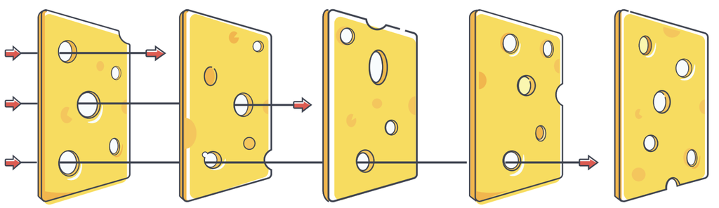

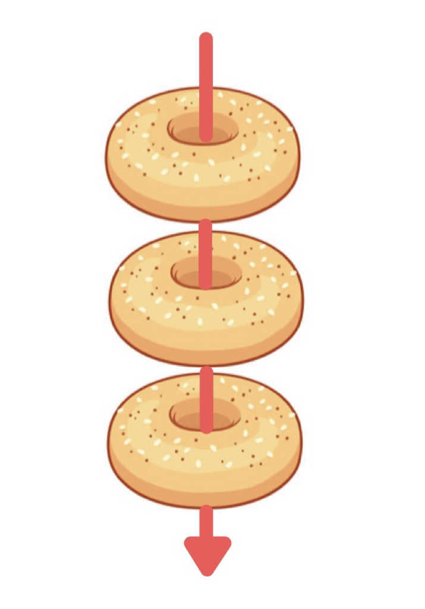

## The six flaws

| Flaw | Description | Cuellar et al. framing |
| --- | --- | --- |
| A | Inadequate sample size | Exacerbates the other flaws |
| B | Non-representative sample (examiners, firearms, ammunition) | Damages the data |
| C | Non-representative testing conditions | Damages the data |
| D | Inconclusives treated as correct or ignored | Fixable if raw responses available |
| E | Invalid or nonexistent uncertainty measures | Fixable if raw responses available |
| F | Missing data handled inappropriately | Fixable if missingness can be characterized |

## Where we agree with Chin et al.

- No single study is perfect
- Not every flaw has the same consequences
- Analytic shortcomings may be **repairable after the fact** if the raw responses were recorded
- Imperfect studies are still useful!
- We should not discourage data collection just because a study has flaws

> The problem is not simply that the wrong quantity was reported. The problem is that the data needed to estimate the relevant quantity were never collected in the first place.

## What does it mean for a flaw to be “remediable”?

- Define the target quantity (the **estimand**)

The population-average sensitivity (P(ID|Same Source)) and specificity (P(Elimination|Different Source)), under casework-representative firearms, ammunition, examiners, and testing conditions.

- A flaw is **remediable** if, given the raw examiner-by-item responses, the estimand can still be estimated correctly (possibly with extra assumptions/new analyses)
- A flaw is **non-remediable** if the sampled data cannot recover the estimand, *regardless* of what analysis is applied to them

## Flowchart: sorting the six flaws

[figure not shown]

## Remainder of the talk

1. Simulation Framework
2. Remediable flaw example: Inconclusives
3. Non-remediable flaw example: Non-representative samples

## Approach: simulation study

- We can’t go back and observe the “true” error rate for the 28 studies
- A simulation with a **known estimand** lets us show what each flaw does to a study’s conclusions
- Same generative model powers both case studies

|  | Identification | Inconclusive | Elimination |
| --- | --- | --- | --- |
| Same-source (SS) | Correct | Inconclusive | False negative |
| Different-source (DS) | False positive | Inconclusive | Correct |

## Data generating model

Target estimand: overall population FPR or FNR or IR is **fixed** for each simulation

- Each item $i$ has a latent difficulty $d_i \sim N(0, \sigma_d^2)$
- Each examiner $j$ has a latent skill $s_j \sim N(0, \sigma_s^2)$ **and** a latent tendency to call items inconclusive $\tau_j \sim N(0, \sigma_\tau^2)$
- Pairing item $i$ with examiner $j$ creates a decision challenge: $c_{ij} = d_i - s_j$
  - this becomes an “offset” from the overall estimand

## Response probabilities

$P(\text{Error})$ and $P(\text{Inconclusive})$ are both shifted by $c_{ij}$

$$\pi_{ij}^{err} = P(\text{error}) = \text{expit}[\text{logit}(\text{FPR or FNR}) + c_{ij}]$$

$P(\text{Inconclusive})$ is also shifted by $\tau_j$

$$\pi_{ij}^{inc} = P(\text{Inconclusive}) = \text{expit}[\text{logit}(\text{IR}_{G_i}) + 0.5 \cdot c_{ij} + \tau_j]$$

The baseline inconclusive rate $\text{IR}_{G_i}$ can differ for same-source and different-source items.

## The response, formally

$e(\cdot)$ denotes an error and $c(\cdot)$ denotes a correct response. $G_i$ indicates ground truth (SS or DS)

$$R_{ij} \mid G_i, c_{ij}, \tau_j \;\sim\;
\begin{cases}
e(G_i) & \pi^{err}_{ij} \\
\text{inconclusive} & \pi^{inc}_{ij} \\
c(G_i) & 1 - \pi^{err}_{ij} - \pi^{inc}_{ij}
\end{cases}$$

independently across $(i,j)$ given the latent variables above.

## Calibrating to real studies

$$R_{ij} \mid G_i, c_{ij}, \tau_j \;\sim\;
\begin{cases}
e(G_i) & \pi^{err}_{ij} \\
\text{inconclusive} & \pi^{inc}_{ij} \\
c(G_i) & 1 - \pi^{err}_{ij} - \pi^{inc}_{ij}
\end{cases}$$

- Probability model above *cannot* capture every effect that arises in real data
- Goal is to create simulated studies that resemble previously-collected results
- We used Ames II to benchmark most parameters:
  - Cartridge cases (raw responses): baseline FPR, FNR, and inconclusive rates, fit by maximum likelihood
    - same-source and different-source items get *separate* inconclusive baselines: about 17% vs. 50%
  - $\sigma_\tau$, $\sigma_s$, $\sigma_d$ were estimated using profile maximum likelihood
  - $h$: rate of “misleading” inconclusives. Ames II examiners also recorded *which way* an inconclusive leaned. (12% DS and 7% SS)

Disagree with these numbers? We have an app for that! https://aluby-icfis-simulation.share.connect.posit.cloud/

## Calibrating to real studies: gut check

|  | Identification | Inconclusive | Elimination |
| --- | --- | --- | --- |
| Same-source (SS) | 0.74 | 0.24 | 0.02 |
| Different-source (DS) | 0.01 | 0.51 | 0.48 |

### Simulated Data:

|  | Identification | Inconclusive | Elimination |
| --- | --- | --- | --- |
| Same-source (SS) | 0.67 | 0.30 | 0.03 |
| Different-source (DS) | 0.01 | 0.44 | 0.55 |

# Case Study 1: A Remediable Flaw

## Setup: inconclusive handling (Flaw D)

In the 2x2 setting, reporting the **error rates** is analagous to reporting **sensitivity** and **specificity**

2×2 analog: identification / elimination

|  | Identification | Elimination |
| --- | --- | --- |
| Same-source (SS) | Correct | False negative |
| Different-source (DS) | False positive | Correct |

In the 2x3 setting, there’s no way to reconstruct the sensitivity/specificity from the error rates alone (and vice-versa)

2×3: identification / inconclusive / elimination

|  | Identification | Inconclusive | Elimination |
| --- | --- | --- | --- |
| Same-source (SS) | Correct | Inconclusive | False negative |
| Different-source (DS) | False positive | Inconclusive | Correct |

## Setup: inconclusive handling (Flaw D)

- Black-box studies handle inconclusive responses inconsistently
  - Often, inconclusives are included in the denominator of the error rate
  - Sometimes, inconclusives are removed entirely when reporting error rates
- Cuellar et al. (2024) recommend a bounding procedure instead: recode every inconclusive as an identification, then as an elimination, and report **both** recomputed error rates as a range
- Claim: this flaw is *remediable* — both numbers come from the same raw responses, recomputed after the fact

## Simulation design

- Same DGP as earlier, under an incomplete design (50 examiners, 30 of 300 items each)
- For each simulated study, compute both numbers from the same raw responses:
  - **Reported**: identifications / all different-source cases (and the same-source analog for the false negative rate)
  - **Worst case**: recode every inconclusive as the error-favoring label, recompute
- Compare to the “true” error rate (FPR/FNR + $h \cdot$ Inc)
- Repeat across 100 replicate studies

## Results

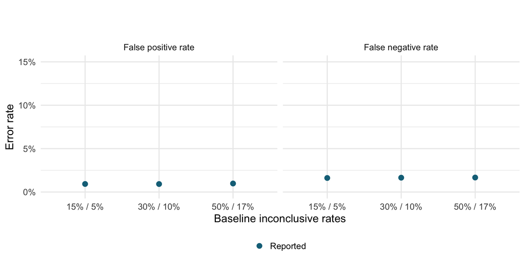

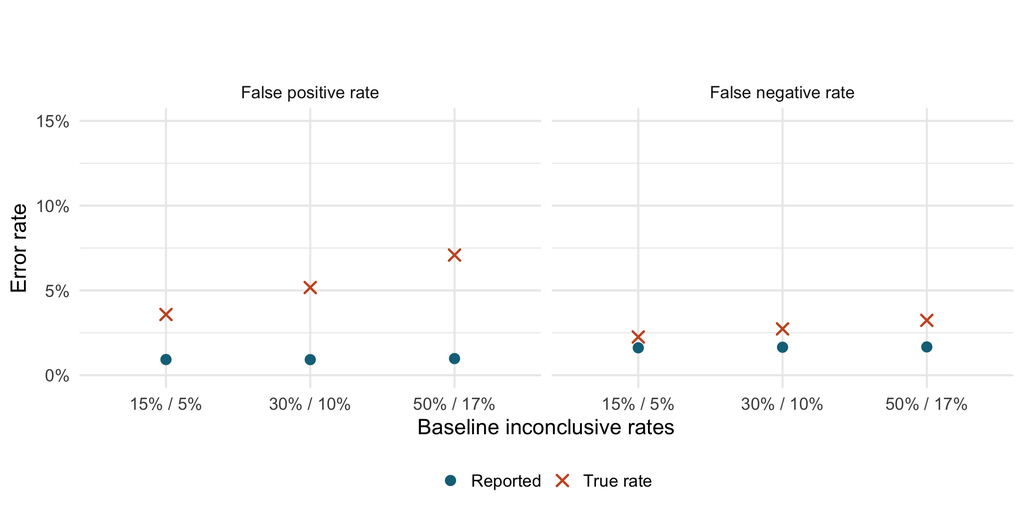

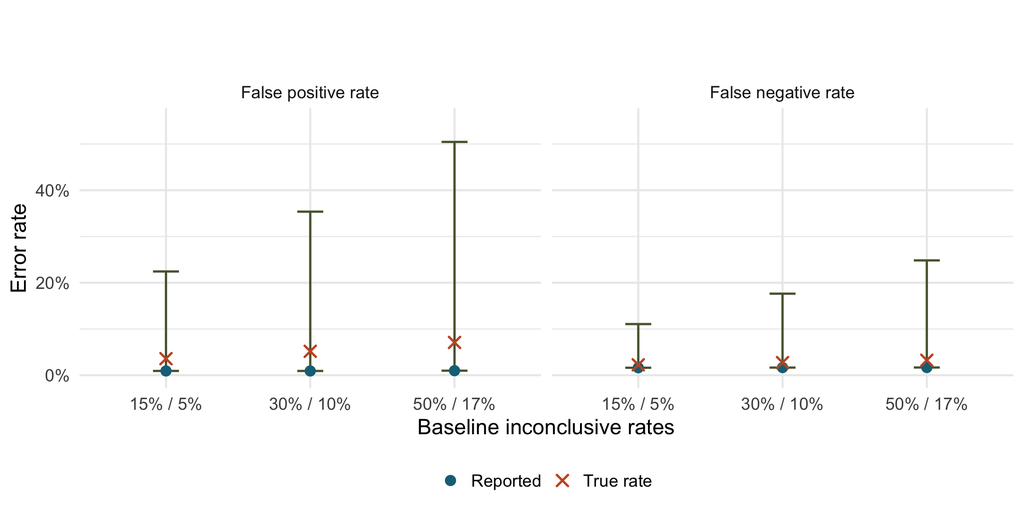

## Why this counts as remediable

- The fix required **no new data collection**. Only how they’re summarized changed
- A study with this flaw alone can still contribute to a cumulative evidence base, *once reanalyzed*
- On the other hand, these intervals are so large that this isn’t really a “solution”
  - More research is needed: “forced choice” reporting, blind test cases, Hawthorne effect, etc.

# Case Study 2: A Non-Remediable Flaw

## Setup: non-representative sampling (Flaw B)

- Precondition for validity: firearms, ammunition, and examiners must represent the **full spectrum of real casework** (Cuellar et al. 2024)
- None of the 28 studies demonstrate this
- Chin et al.’s response: non-representative samples can still contribute to a cumulative literature if combined with other studies

## Ames II: differences between firearm type

- 11 Ruger and 27 Beretta firearms were used to generate test cases
- Beretta had *fewer* inconclusives on ground truth same-source, and *more* inconclusives on ground truth different source

| Type | SS | DS |
| --- | --- | --- |
| Beretta | 0.184 | 0.534 |
| Ruger | 0.323 | 0.442 |

→ Support for a “type” effect

## Ames II: differences within firearm type

Some firearms produce markings that are easier/harder to compare

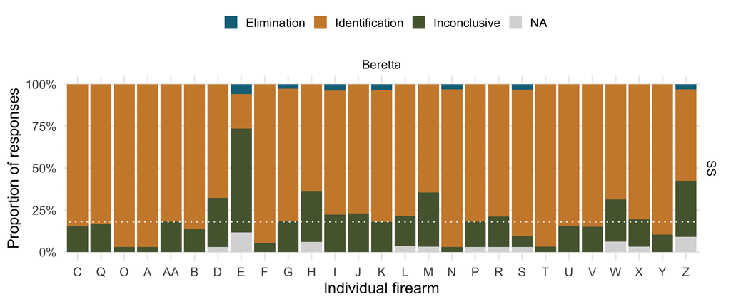

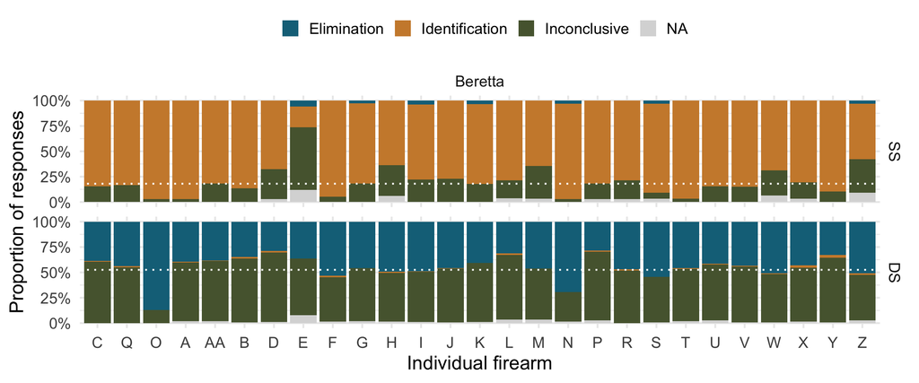

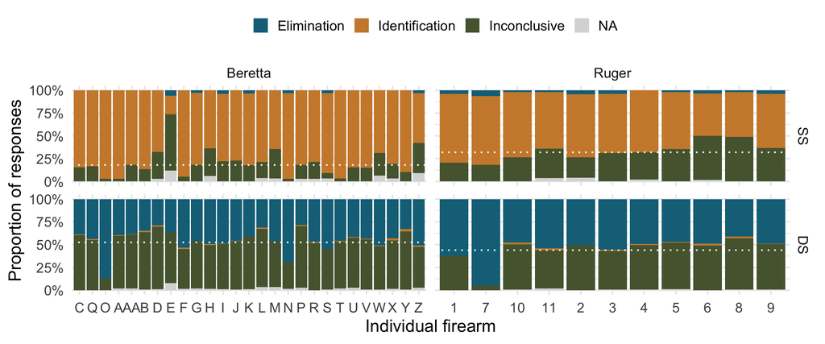

→ support for individual firearm effect

## Two levels of variability

- Different firearm makes/models have different baseline difficulties
  - **Simulation:** simulate baseline/mean for 8 types.
- Individual firearms *within* a make/model also have different difficulties
  - **Simulation:** assume a difficulty distribution for each firearm type; draw individual firearms from that distribution
- Every scenario below draws 80 individual firearms total, spread across however many types are included
  - Ames II: used ~38 (27 Beretta, 11 non-Beretta)

## Three different “study” approaches:

Casework “population” of firearms: 8 types at different proportions

1. **Convenience sample:** test cases are drawn from two firearm types (21% of casework by weight), 40 firearms each (80 total)
2. **Stratified sample + reweighting:** A hypothetical alternative study covering all eight types (10 firearms each, not in population-correct proportions) with type recorded as a covariate
3. **Reweighting the convenience sample:** Applying reweighting to the convenience sample from (1), which has zero data on the six unsampled types.

## Simulation grid

Tested all 3 study designs across three levels of **examiner** heterogeneity and **difficulty** heterogeneity with 200 replicates per combination

**Difficulty heterogeneity**

- Low: $\sigma_{\text{type}} = .6$, $\sigma_{\text{individ}} = .45$
- Medium: $\sigma_{\text{type}} = 1.2$, $\sigma_{\text{individ}} = .9$
- High: $\sigma_{\text{type}} = 1.8$, $\sigma_{\text{individ}} = 1.35$

**Examiner heterogeneity**

- Low: $\sigma_{\text{s}} = .25$
- Medium: $\sigma_{\text{s}} = .5$
- High: $\sigma_{\text{s}} = 1$

We’ll compare **estimated rate** from each study to the **true rate** from the population. Inconclusives are ignored for this simulation.

## Reweighting the convenience sample doesn’t work

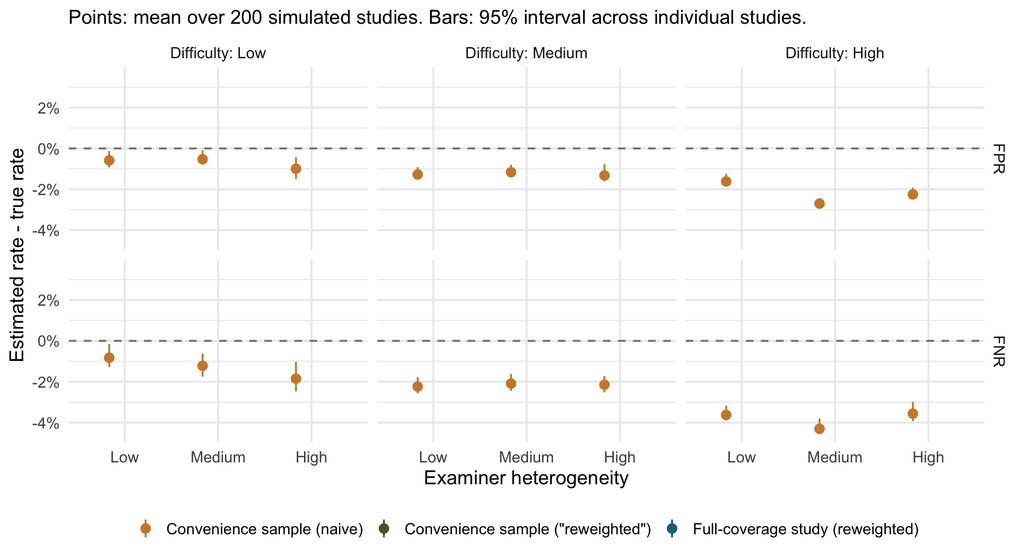

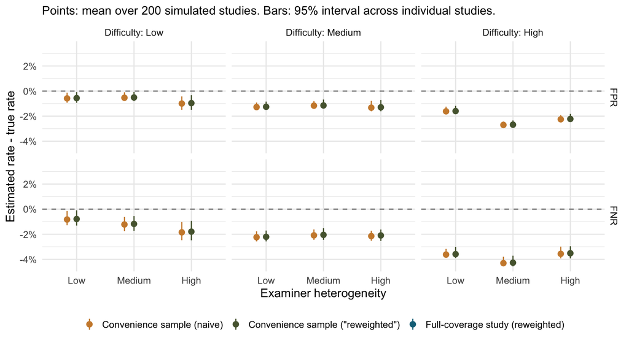

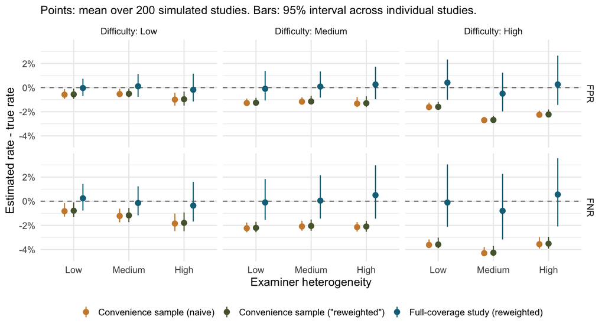

## Why this counts as non-remediable

- No statistical procedure applied to the convenience samples can recover the population-average estimand
- Fixing it requires **new data** collected under a design that characterizes the target population — not a different analysis of the same responses

# Conclusion

## Flowchart, again

[figure not shown]

## Takeaways

- Not all six flaws have the same consequences
  - sorting by *remediable vs. non-remediable* clarifies where the “cumulative-science” argument applies
- **Remediable** (maybe A, D, E, and F with assumptions): reanalysis of existing data, or combining data from multiple studies, can recover a valid estimate
- **Non-remediable** (B, C): the target quantity was never within reach of the sampled data

## Recommendations

- Report raw, examiner-by-item responses (not just summary error/inconclusive rates)
  - enables post-hoc correction of remediable flaws
- Pre-register sampling frames
  - characterize the target population of firearms / examiners *before* data collection
- Use cluster-aware / MRMC statistical methods designed for the dependence structure of validation studies

## Thank you

- Amanda Luby `aluby@carleton.edu`
- Maria Cuellar `mcuellar@sas.upenn.edu`
- Code and simulations: `github.com/aluby/icfis-2026-talk`
- Shiny app: `https://aluby-icfis-simulation.share.connect.posit.cloud/`

### References

Chin, Jason M., Bethany Growns, Kylie E. Hunter, Adele Quigley-McBride, Rachel A. Searston, Stephanie Summersby, Matthew B. Thompson, and Alice Towler. 2026. “Towards Cumulative Forensic Science: A Commentary on Methodological Problems in Every Black-Box Study of Forensic Firearm Comparisons.” *Law, Probability and Risk* 25 (1): mgaf016. https://doi.org/10.1093/lpr/mgaf016.

Cuellar, Maria, Susan Vanderplas, Amanda Luby, and Michael Rosenblum. 2024. “Methodological Problems in Every Black-Box Study of Forensic Firearm Comparisons.” *Law, Probability and Risk* 23 (1): mgae015. https://doi.org/10.1093/lpr/mgae015.

Monson, K. L., E. D. Smith, and E. M. Peters. 2023. “Accuracy of Comparison Decisions by Forensic Firearms Examiners.” *Journal of Forensic Sciences* 68 (1): 86–100. https://doi.org/10.1111/1556-4029.15152.

# Backup Slides

## Appendix: contextual-bias extension (Flaw C)

Hawthorne shift, calibrated to Scurich et al. (2025) blind vs. known-test inconclusive rates at the Houston Forensic Science Center:

$$\delta_H = \operatorname{logit}(0.564) - \operatorname{logit}(0.393)$$

Under the “known test” condition, the inconclusive-probability equation gains one term (error probability is unaffected):

$$\pi^{inc}_{ij}(\text{condition}) = \operatorname{expit}\Big[\operatorname{logit}(p_{IC}) + 0.5\,c_{ij} + \tau_j + \delta_H \cdot \mathbb{1}\{\text{condition} = \text{"known test"}\}\Big]$$

## Appendix: missingness extension (Flaw F)

$$\text{error}_{ij} = \mathbb{1}\{R_{ij} = e(G_i)\}$$

$$\pi^{miss}_{ij} = \operatorname{expit}\Big[\operatorname{logit}(0.05) + 0.8\,c_{ij} + 1.2\cdot\text{error}_{ij} + 0.6\cdot\mathbb{1}\{R_{ij}=\text{inconclusive}\}\Big]$$

$$M_{ij} \sim \text{Bernoulli}(\pi^{miss}_{ij}), \qquad
R^{obs}_{ij} = \begin{cases} R_{ij} & M_{ij} = 0 \\ \texttt{NA} & M_{ij} = 1 \end{cases}$$

A missing-not-at-random mechanism: harder pairs, errors, and inconclusives are all more likely to drop out, which is what biases naive (listwise- deletion) error rates downward.

## Appendix: what’s left for CI coverage (Flaw E)

Can re-use simulation infrastructure from Case Study 2:

- Case study 2 uses the firearm layer for a **bias** demonstration (does reweighting recover the population mean?) — it never constructs a confidence interval
- A Flaw E case study needs the same nested structure feeding an actual **interval-coverage** comparison: simulate many studies from a known true rate, compute a 95% CI three ways per study (naive Clopper–Pearson, cluster-robust, Gallas et al. 2009-style MRMC), and check what fraction of intervals actually contain the truth
- Responses for items sharing a firearm are **dependent** given $f_k$ — exactly what a naive interval ignores and a cluster-robust one accounts for; this is a different question from case study 2’s, even though the generative structure is shared

## Appendix: FDA precedent for bounding equivocal results

FDA’s guidance on diagnostic tests flags discarding equivocal results as a common source of bias:

“If a test can (per the test instructions) produce a result which is anything other than positive or negative then it is not technically a qualitative test… Discarding or ignoring these results and performing the calculations in this guidance will likely result in biased performance estimates.”

Its recommended fix is the same two-sided bound used in Case Study 1:

“To address this issue, one option is to report two different sets of performance measures — one set of measures based on including the equivocal results with the test positive results [and] a second set of measures based on including the equivocal results with the test negative results.”